# Vignette_almaso

almaso

2023-01-20

# **Vignette: Flow cytometry data analysis workflow**

The goal of the project was to build a pipeline to analyse flow cytometry data in the manner of scRNA-Seq. This present vignette will present a full analysis using the *almaso* package. The functions used in this vignette are stored in the file *pipeline_functions.R*.

To sum up, the pipeline goes through all those steps:

1. Load the datas
2. Pre-processing
3. Dimension Reduction
4. Clustering
5. Differential expression and identification of markers
6. [Biological interpretation]

### Libraries

The *renv* environment store every package necessary in the right version. Be careful to have all packages imported, present in the environment.

```r
{
  library(flowCore)
  library(flowAI)
  library(ggcyto)
  library(PeacoQC)
  library(data.table)
  library(Seurat)
  library(ggplot2)
  library(tidyverse)
  library(gridExtra)
  library(ggrepel)
  library(dplyr)
  library(uwot)
  library(FlowSOM)
  library(ggcorrplot)
  library(ggfortify)
  library(factoextra)
  library(edgeR)
}
```

## Load the datas

Flow Cytometry data are stored in *.fcs* files. The library **flowCore** provides data structures and basic functions to deal with those kind of data. They can be loaded as *flowFrame* or *flowSet*. The *flowFrame* class represents the data contained in a FCS file. Load with the function *read.flowFrame()*, a *flowFrame* contains:

- a numeric matrix **exprs** of the raw measurement values ( columns = markers, rows = cells)
- an object of class *AnnotatedDataFrame* **parameters** that describe the parameters (e.g., the measurement channels, stains, dynamic range)
- additional annotations provided through keywords in the FCS file (**description**), like the antigene names

A *flowSet* is a countainer of one or multiple *flowFrames*. Because most of pre-processing functions are made for *flowSets,* in this vignette, we will load 1 dataset as *flowSets* (control sample). The *.fcs* file used here is stored in the *data* directory.

The matrix of expression is composed of 69 421 cells (lines) and 20 parameters (columns): 6 structural parameters (FSC, SSC…), that gives information about cell size and cell complexity, and 13 fluorescent markers, that stain for specific antigenes. The time at which each cell passes through the laser is saved in the last column *Time* and used to identify each cell. For this analysis, it will not be relevant. That is why we don’t import this column.

The *truncate_max_range* argument is set to FALSE, because flow cytometry data have large range that can be truncated to simplified processing. Here we want to keep all information.

```r
file_name_control = "cd45pos2_control_CD45+.fcs"
path_control <- file.path("./data", file_name_control)

control_sample = read.flowSet(path_control, column.pattern = "Time", invert.pattern = TRUE, truncate_max_range = FALSE)

control_sample
```

```
## A flowSet with 1 experiments.
##
## column names(19): FSC-A FSC-H ... FJComp-V450-A FJComp-V500-A
```

Here are summarized some commands from the **flowCore** package that are useful to access and examine *flowSets* objects. For more informations, please review the **flowCore** Reference Manual (https://bioconductor.org/packages/release/bioc/manuals/flowCore/man/flowCore.pdf).

You can extract a particular *flowFrame* from a *flowSet* with the command below. Here, because *control-sample* only contains 1 *flowFrame*, we take the first (and only frame).

```r
control_sample[[1]]  # Extract the 1st flowFrame of the control_sample flowSet
```

```
## flowFrame object 'cd45pos2_control_CD45+.fcs'
## with 69421 cells and 19 observables:
##                       name   desc     range  minRange  maxRange
## $P1                  FSC-A     NA    262144         0    262143
## $P2                  FSC-H     NA    262144         0    262143
## $P3                  FSC-W     NA    262144         0    262143
## $P4                  SSC-A     NA    262144         0    262143
## $P5                  SSC-H     NA    262144         0    262143
## ...                    ...    ...       ...       ...       ...
## $P15       FJComp-PE-Cy7-A   Ly6C    262144      -111    262143
## $P16 FJComp-PE-Texas Red-A    Lin    262144      -111    262143
## $P17  FJComp-PerCP-Cy5-5-A   Ly6G    262144      -111    262143
## $P18         FJComp-V450-A   XCR1    262144      -111    262143
## $P19         FJComp-V500-A  CD11c    262144      -111    262143
## 211 keywords are stored in the 'description' slot
```

## Pre-processing

The first step of our pipeline is to preprocess the data in order to clean them for further analysis. Our pre-processing pipeline contains 3 steps :

- **Compensation** : control the spillover phenomenon happening during the fluorescence detection.
- **Quality control** : remove outliers and anomalies.
- **Normalization** : scale and normalization (TMM and logCPM) on the expression matrix.

### Compensation

The idea is to compensate for spillover between channels by applying a spillover matrix to a *flowFrame*. Some detectors may register fluorochroms signals that do not correspond to them. So, to compensate for this phenomenon, a spillover matrix (that expresses background noise and secondary signals for each channel) is applied the expression matrix (as a linear combination).

Some flow cytometry dataset may already be compensated, so be careful. Here our data was already compensate, so the code is only an example. We use the *compensate()* function from **flowCore**.

```r
if(exists("control_sample[[1]]@description$`$SPILLOVER`")){
  comp.mat <- control_sample[[1]]@description$`$SPILLOVER`
  control_sample_comp <- compensate(control_sample, comp.mat)
}
```

### Quality control

The goal of quality control (QC) is to remove outliers and anomalies. For that, we choose 2 libraries that can both do QC.

First is **flowAI**. It guarantee the stability of flow rate (remove flowrates that deviate from the median), the stability of signal acquisition ( intensity should always stay the same, detect deviations to the mean) and also the signal dynamic range consistency (remove outliers with Z-score and negatives values). The *flow_auto_qc* is a function of the **flowAI** package. It will create a file with graphs to explain the analysis conducted. In this vignette, it is not the QC method chosen.

```r
control_sample_qcAI <- flow_auto_qc(control_sample)
```

Second is **peacoQC**. It determines peaks on the channels in the *flowframe*. Then it will remove outliers and anomalies caused by e.g. clogs, changes in speed etc. by using an IsolationTree and/or the MAD method.

The *peaco_QC()* function is from our package. It is using the *PeacoQC* function from the **peacoQC** package. The return object *control_sample_peacoQC* is a flowSet. A directory *PeacoQC_results* will be created, containing the data cleaned and some graphs.

```r
control_sample_peacoQC <- peaco_QC(control_sample, file_name_control)
```

```
## Starting quality control analysis for cd45pos2_control_CD45+.fcs
```

```
## Calculating peaks
```

```
## IT analysis removed 0% of the measurements
```

```
## MAD analysis removed 3.24% of the measurements
```

```
## The algorithm removed 3.24% of the measurements
```

```
## Saving fcs file
```

To visualize the results of the cleaning method, the heat-map from *PeacoQCHeatmap()* can be interesting.

```r
PeacoQCHeatmap("./PeacoQC_results/PeacoQC_report.txt")
```

[output not shown]

### Normalization & scaling:

First we extract the expression matrix from the cleaned dataset.

```r
exp_mat_control <- exprs(control_sample_peacoQC[[1]])
summary(exp_mat_control)
```

```
##      FSC-A            FSC-H            FSC-W           SSC-A
##  Min.   : 26408   Min.   : 20476   Min.   :59173   Min.   :  3911
##  1st Qu.: 63893   1st Qu.: 58506   1st Qu.:68826   1st Qu.: 31045
##  Median : 79857   Median : 74664   Median :70641   Median : 50635
##  Mean   : 86990   Mean   : 77530   Mean   :72536   Mean   : 77678
##  3rd Qu.:101453   3rd Qu.: 90559   3rd Qu.:75038   3rd Qu.:113029
##  Max.   :241130   Max.   :209057   Max.   :93788   Max.   :247287
##      SSC-H            SSC-W        FJComp-APC-A       FJComp-APC-Cy7-A
##  Min.   :  3513   Min.   :52897   Min.   :-83185.07   Min.   :-1386.27
##  1st Qu.: 31399   1st Qu.:64408   1st Qu.:   -40.65   1st Qu.:   48.99
##  Median : 49227   Median :66934   Median :    40.47   Median :  100.82
##  Mean   : 70417   Mean   :69252   Mean   :    50.46   Mean   :  149.10
##  3rd Qu.:100773   3rd Qu.:72893   3rd Qu.:   124.77   3rd Qu.:  206.37
##  Max.   :257851   Max.   :95008   Max.   :157085.14   Max.   : 1140.47
##  FJComp-Alexa Fluor 700-A FJComp-DAPI-A    FJComp-FITC-A
##  Min.   :-10640.30        Min.   :  -781   Min.   :  -582.0
##  1st Qu.:   -15.52        1st Qu.:  2317   1st Qu.:    42.4
##  Median :   138.97        Median :  4817   Median :   228.4
##  Mean   :  2942.77        Mean   : 13549   Mean   :  1749.7
##  3rd Qu.:  2268.21        3rd Qu.: 15518   3rd Qu.:  2751.2
##  Max.   :162954.80        Max.   :258587   Max.   :262124.5
##  FJComp-Hoechst Red-A  FJComp-PE-A       FJComp-PE-Cy5-A     FJComp-PE-Cy7-A
##  Min.   :  2300       Min.   :-17547.6   Min.   :  -858.41   Min.   :-13215.1
##  1st Qu.:  7060       1st Qu.:   207.6   1st Qu.:    61.61   1st Qu.:   130.3
##  Median : 16190       Median :   680.6   Median :   331.08   Median :   396.9
##  Mean   : 18870       Mean   :  2682.5   Mean   :  1274.47   Mean   :  5718.5
##  3rd Qu.: 26750       3rd Qu.:  2145.6   3rd Qu.:   934.54   3rd Qu.:  1631.2
##  Max.   :116371       Max.   :260702.2   Max.   :199102.73   Max.   :157524.7
##  FJComp-PE-Texas Red-A FJComp-PerCP-Cy5-5-A FJComp-V450-A
##  Min.   : -8054        Min.   :-118766.60   Min.   :-103581.7
##  1st Qu.:   470        1st Qu.:      8.26   1st Qu.:    115.8
##  Median :  4529        Median :    232.93   Median :    329.2
##  Mean   :  8192        Mean   :    554.37   Mean   :   2265.3
##  3rd Qu.: 11893        3rd Qu.:    516.35   3rd Qu.:   1386.0
##  Max.   :261735        Max.   : 182783.94   Max.   : 239092.6
##  FJComp-V500-A       Original_ID
##  Min.   :  -400.1   Min.   :    1
##  1st Qu.:   116.9   1st Qu.:19044
##  Median :   442.6   Median :35836
##  Mean   :  2049.2   Mean   :35696
##  3rd Qu.:  2184.3   3rd Qu.:52629
##  Max.   :267307.8   Max.   :69421
```

To normalize data, we decided to treat the flow cytometry data as scRNA-Seq data. So we used logCPM normalization on the expression matrix. But first the function *norm_cyto()* sets every negative value of expression matrix to 0 and removes the non useful column (*Original_ID*) created by peaco_QC(). It then performs the logCPM normalization.

```r
exp_mat_cpm <- norm_cyto(exp_mat_control)
summary(exp_mat_cpm)
```

```
##      FSC-A            FSC-H            FSC-W           SSC-A
##  Min.   : 4.519   Min.   : 3.932   Min.   :12.14   Min.   : 0.7496
##  1st Qu.:10.935   1st Qu.:11.234   1st Qu.:14.13   1st Qu.: 5.9500
##  Median :13.667   Median :14.337   Median :14.50   Median : 9.7045
##  Mean   :14.887   Mean   :14.887   Mean   :14.89   Mean   :14.8874
##  3rd Qu.:17.362   3rd Qu.:17.389   3rd Qu.:15.40   3rd Qu.:21.6627
##  Max.   :41.267   Max.   :40.144   Max.   :19.25   Max.   :47.3939
##      SSC-H             SSC-W        FJComp-APC-A       FJComp-APC-Cy7-A
##  Min.   : 0.7427   Min.   :11.37   Min.   :    0.000   Min.   :  0.000
##  1st Qu.: 6.6383   1st Qu.:13.85   1st Qu.:    0.000   1st Qu.:  4.545
##  Median :10.4075   Median :14.39   Median :    5.901   Median :  9.355
##  Mean   :14.8874   Mean   :14.89   Mean   :   14.887   Mean   : 14.887
##  3rd Qu.:21.3053   3rd Qu.:15.67   3rd Qu.:   18.191   3rd Qu.: 19.149
##  Max.   :54.5144   Max.   :20.42   Max.   :22901.826   Max.   :105.824
##  FJComp-Alexa Fluor 700-A FJComp-DAPI-A     FJComp-FITC-A
##  Min.   :  0.0000         Min.   :  0.000   Min.   :   0.0000
##  1st Qu.:  0.0000         1st Qu.:  2.545   1st Qu.:   0.3607
##  Median :  0.6995         Median :  5.292   Median :   1.9425
##  Mean   : 14.8874         Mean   : 14.887   Mean   :  14.8874
##  3rd Qu.: 11.4178         3rd Qu.: 17.050   3rd Qu.:  23.4019
##  Max.   :820.2886         Max.   :284.126   Max.   :2229.6902
##  FJComp-Hoechst Red-A  FJComp-PE-A       FJComp-PE-Cy5-A     FJComp-PE-Cy7-A
##  Min.   : 1.814       Min.   :   0.000   Min.   :   0.0000   Min.   :  0.0000
##  1st Qu.: 5.570       1st Qu.:   1.143   1st Qu.:   0.7049   1st Qu.:  0.3392
##  Median :12.772       Median :   3.748   Median :   3.7880   Median :  1.0327
##  Mean   :14.887       Mean   :  14.887   Mean   :  14.8874   Mean   : 14.8874
##  3rd Qu.:21.104       3rd Qu.:  11.815   3rd Qu.:  10.6925   3rd Qu.:  4.2445
##  Max.   :91.809       Max.   :1435.623   Max.   :2278.0419   Max.   :409.9036
##  FJComp-PE-Texas Red-A FJComp-PerCP-Cy5-5-A FJComp-V450-A
##  Min.   :  0.0000      Min.   :   0.000     Min.   :   0.0000
##  1st Qu.:  0.8532      1st Qu.:   0.198     1st Qu.:   0.7545
##  Median :  8.2217      Median :   5.576     Median :   2.1440
##  Mean   : 14.8874      Mean   :  14.887     Mean   :  14.8874
##  3rd Qu.: 21.5911      3rd Qu.:  12.361     3rd Qu.:   9.0258
##  Max.   :475.1529      Max.   :4375.765     Max.   :1557.0578
##  FJComp-V500-A
##  Min.   :   0.0000
##  1st Qu.:   0.8491
##  Median :   3.2147
##  Mean   :  14.8874
##  3rd Qu.:  15.8648
##  Max.   :1941.4504
```

Let’s now visualize the impact of normalization.

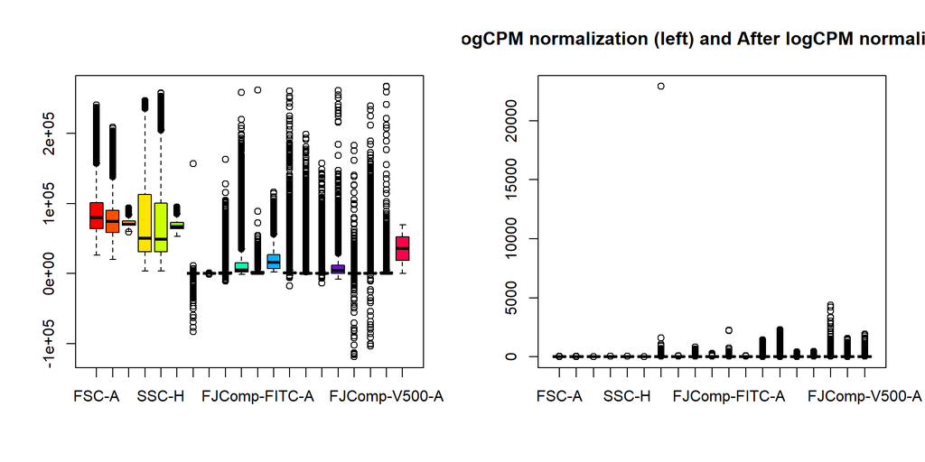

### Some Plots to visualize

The graph SSC=f(FSC) is actually really used during gating technique. Here it is only plot for our information. In this plot nothing is really stand out for our analysis.

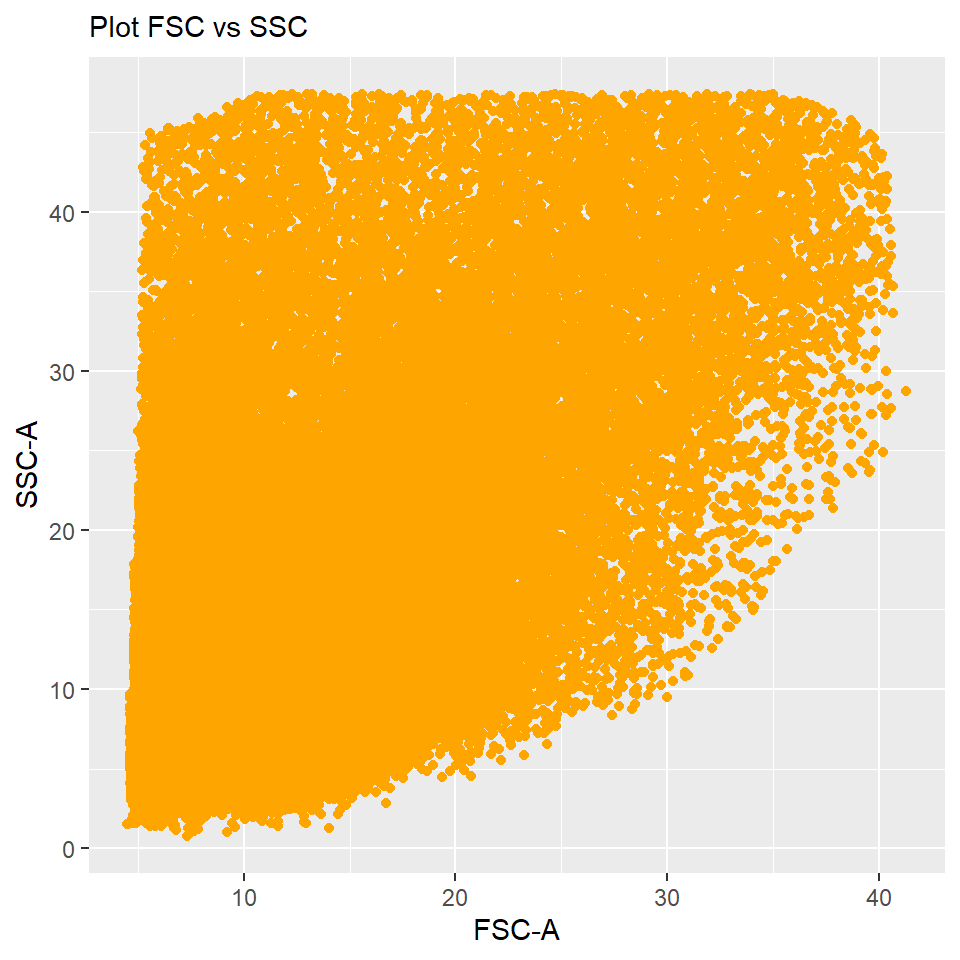

```r
ggplot(as.data.frame(exp_mat_cpm), aes(`FSC-A`,`SSC-A`)) +  geom_jitter(color='Orange' )  +  labs(x = "FSC-A",y = "SSC-A",subtitle = "Plot FSC vs SSC")
```

## Dimension Reduction

Since our dataset is only 20 parameters wide, dimensionality reduction may not appear as useful. But in order to increase separation between clusters, a PCA is recommended. The function *PCA()* is implemented such that we can choose the parameters (here fluorescent markers) on which the PCA will be applied.

Here we applied *PCA()* from the 7th to the 19th parameters (markers) of the expression matrix cleaned and normalized. The function returns the plot of eigenvalues and save the result of the dimension reduction method in the object *pca*. This object is stored automatically in the environment by the function *PCA()*.

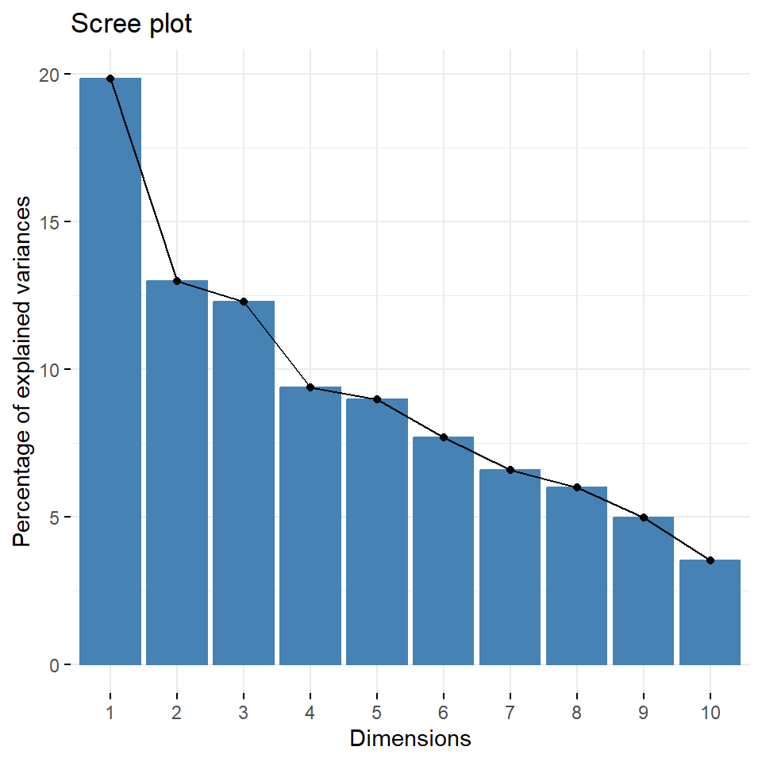

```r
PCA(exp_mat_cpm, 7, 19)
```

```r
summary(pca)
```

```
## Importance of components:
##                           PC1    PC2    PC3     PC4     PC5     PC6     PC7
## Standard deviation     1.6065 1.2991 1.2641 1.10360 1.08002 0.99896 0.92443
## Proportion of Variance 0.1985 0.1298 0.1229 0.09369 0.08973 0.07676 0.06574
## Cumulative Proportion  0.1985 0.3283 0.4513 0.54496 0.63468 0.71145 0.77718
##                            PC8     PC9   PC10    PC11    PC12    PC13
## Standard deviation     0.88303 0.80362 0.6746 0.64477 0.59868 0.49185
## Proportion of Variance 0.05998 0.04968 0.0350 0.03198 0.02757 0.01861
## Cumulative Proportion  0.83716 0.88684 0.9218 0.95382 0.98139 1.00000
```

With this last plot, the number of axes that explain the data can be visually evaluated. With the function *choose_dims_PCA()*, the user is able to chose the number of dimensions to keep, by putting it as parameters.

Here 5 dimensions is taken to conduct our analysis.

```r
df_pca <- choose_dims_PCA(pca, 5)
```

Let’s visualize the first 2 axes of the axes we choose to keep.

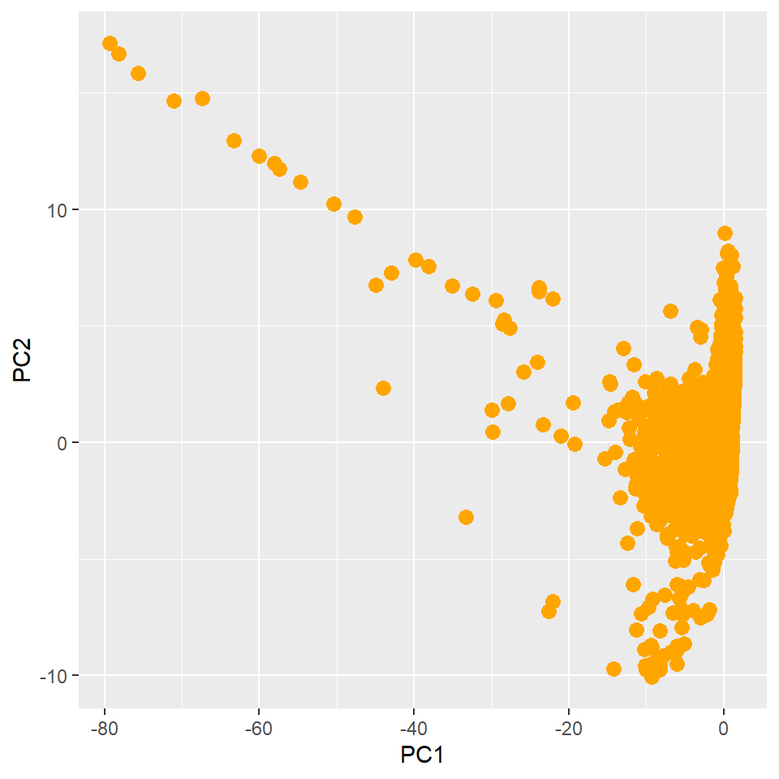

```r
ggplot(data = df_pca, aes_string(x = "PC1", y = "PC2")) + geom_point(size = 3, color= "orange")
```

Here with this graph we can have a look of all variables contribution to the variance.

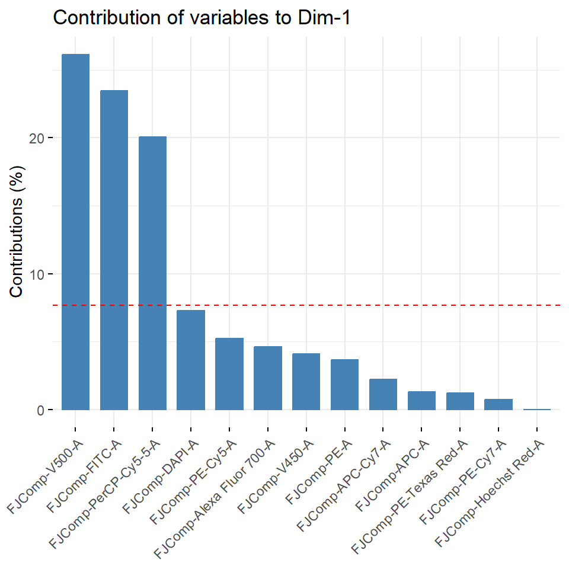

```r
fviz_contrib(pca, "var")
```

## Clustering

To form clusters in our data, the (SNN + Louvain) clustering is applied, which is the same clustering method used in Seurat for scRNA-Seq data analysis. The function *clustering_cyto()* separates and clusters data on the data frame returned by the PCA.

It then attaches to the expression matrix (cleaned and normalized) a column (*cluster_id)* that associates to each cell its cluster’s ID. The result, here stored as df_SNN, is a dataframe (expression matrix + cluster_id).

The third parameter of *clustering_cyto()* is the resolution of the Louvain clustering method. It is recommended to opt for low resolution. By default, it is 0.3. The lower the resolution is, the less clusters will be observed.

```r
df_SNN <- clustering_cyto(df_pca, exp_mat_cpm, 0.3)
# head(df_SNN)
```

In order to have an similar approach to what is usually done on scRNA-Seq data, we decided to do a **UMAP** to display the clustering. The function *RunUMAP_cyto()* plots the UMAP with the clusters and saves a data frame with the UMAP coordinates and the cluster id associated to each cell, called **umap_m** directly in the environment.

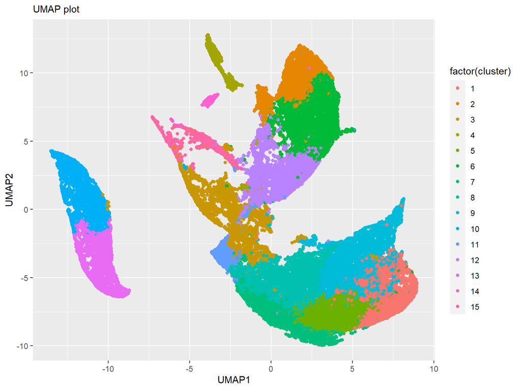

```r
plt_umap <- RunUMAP_cyto(df_SNN, df_pca)
plt_umap
```

### Heatmap and other plots

To have a better overview of the clusters, we can plot a heatmap. The *heatmap_cyto()* function takes the as argument and plot the heatmap of mean expression of each marker in each cluster.

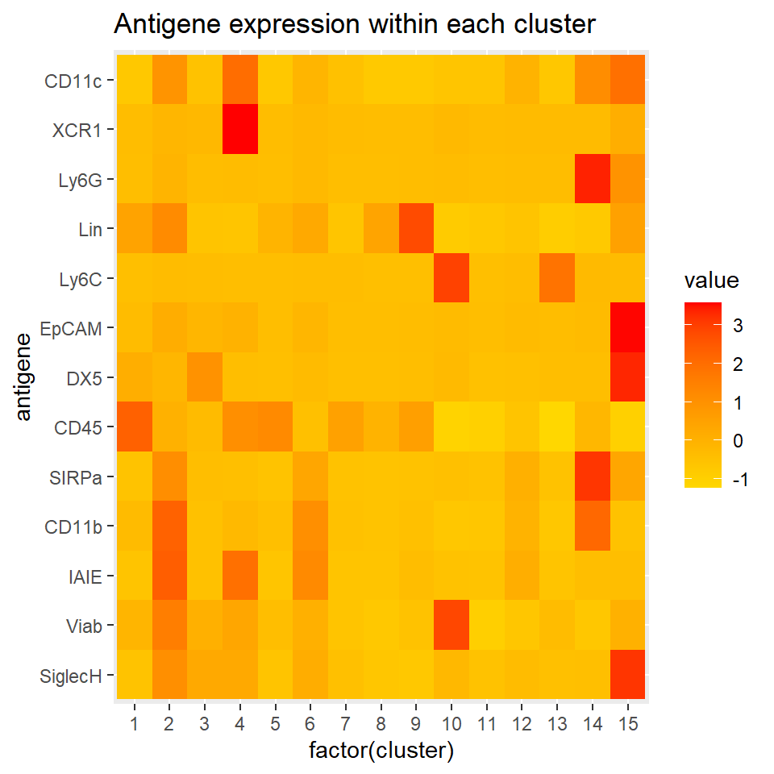

```r
heatmap_cyto(df_SNN,control_sample,file_name_control)
```

Let’s also plot the expression of a specific marker on the UMAP representation with the function *marker_expression()*. It takes as argument the dataframe returned by the clustering, the name of a marker or an antigen, the UMAP coordinates dataframe, the flowSet file and the name of the file.

Here we plot the expression of marker “FSC-A”.

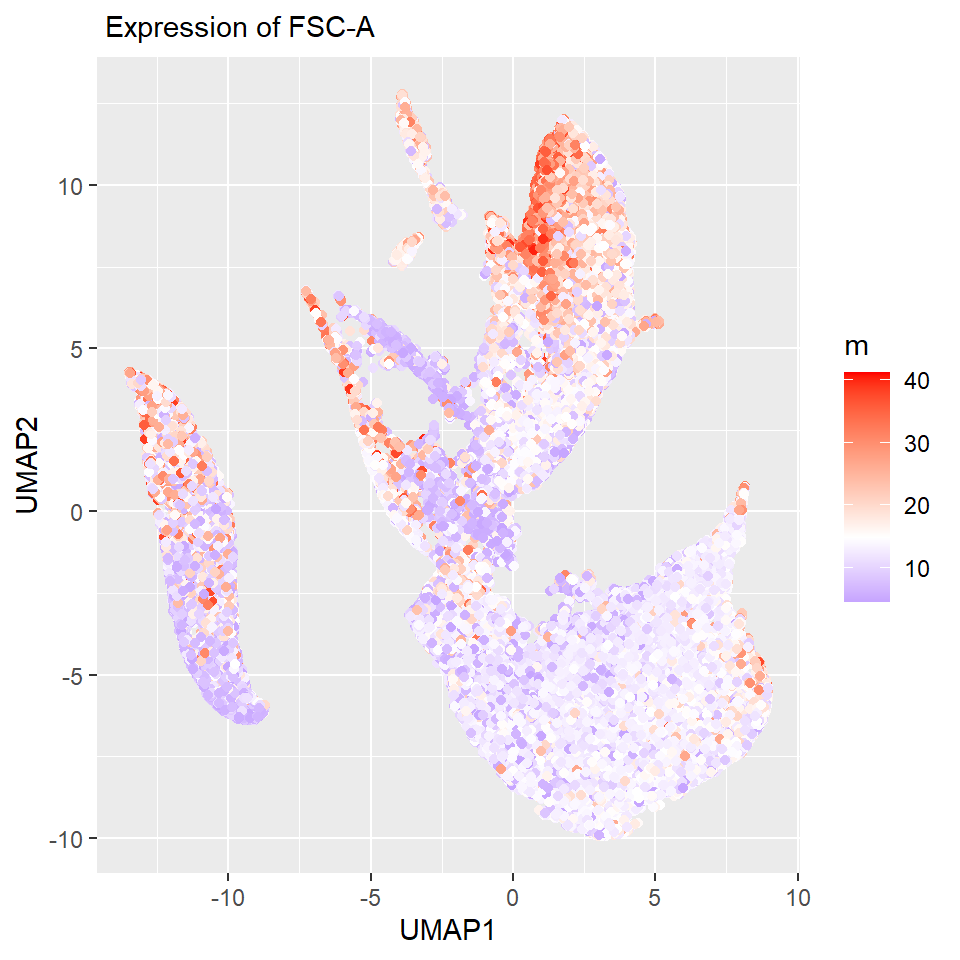

```r
plt_marker <- marker_expression(df_SNN,"FSC-A",umap_m, control_sample, file_name_control)
plt_marker
```

Here we plot the expression of marker liked to the antigen “SiglecH”.

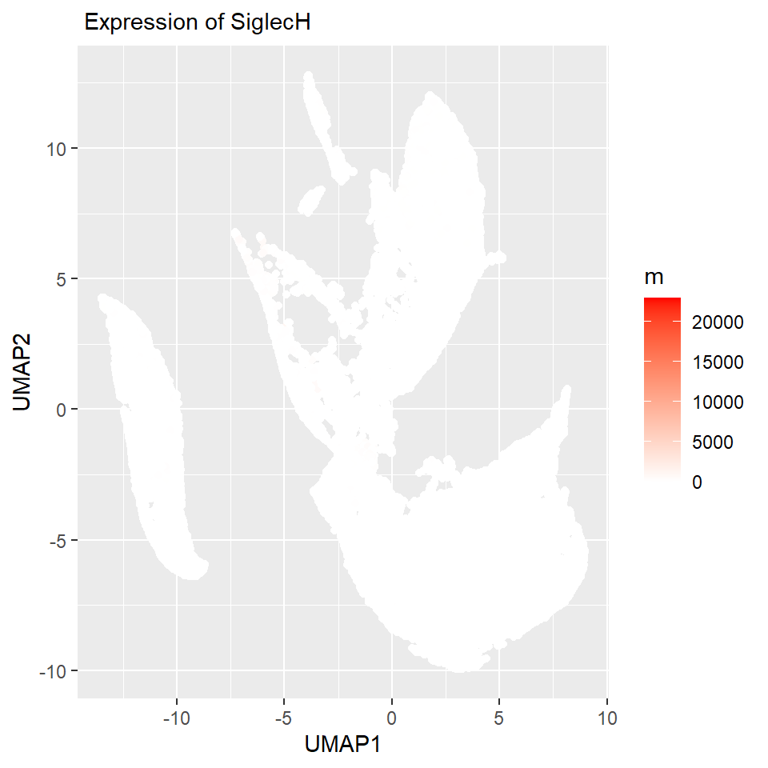

```r
plt_marker <- marker_expression(df_SNN,"SiglecH",umap_m, control_sample, file_name_control )
plt_marker
```

The function *all_markers_expression()* plots the the expression of all fluorescent markers on the UMAP representation. It takes as argument the dataframe returned by the clustering, the UMAP coordinates data frame, the *flowSet* file and the name of the file.

*Be careful, this function takes a lot of time to run, take you time!*.

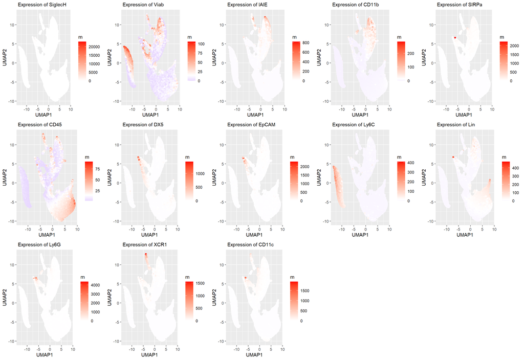

```r
myplots <- all_markers_expression(df_SNN,umap_m, control_sample, file_name_control)
```

Let’s plot the cell counts per cluster to have a better idea of the distribution of all cells in the different clusters.

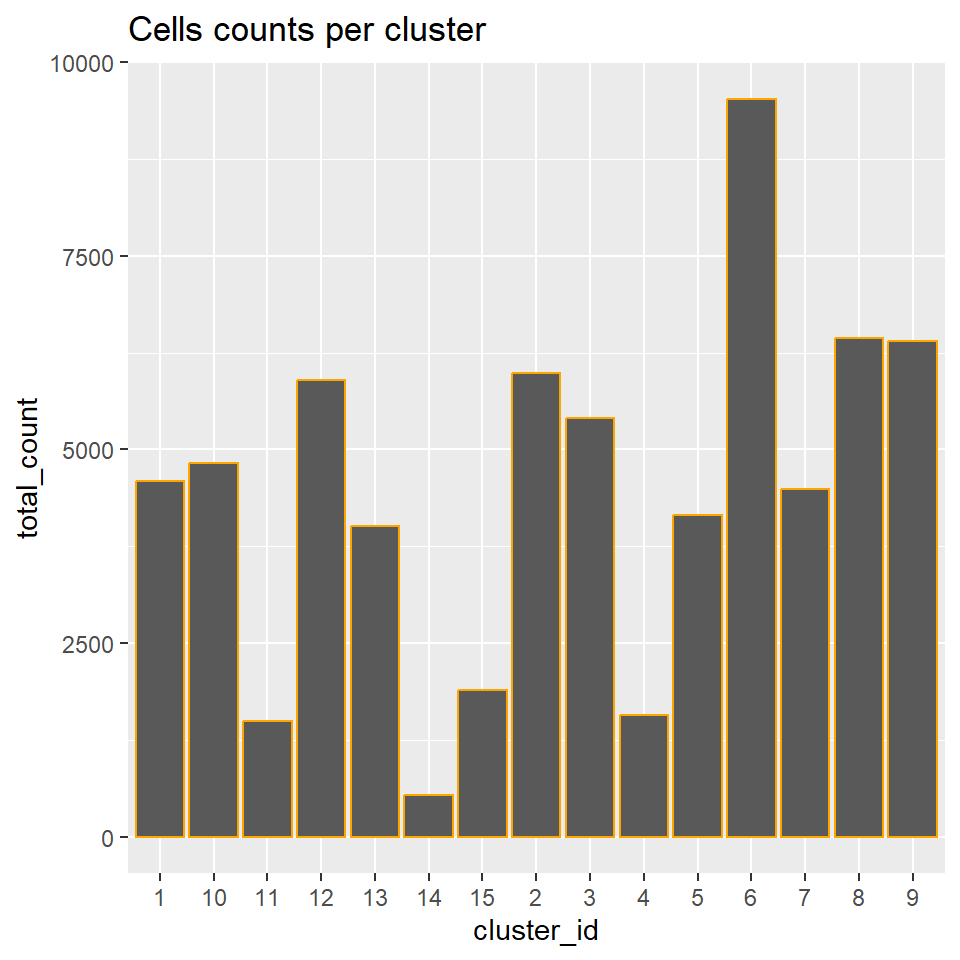

```r
df_SNN %>% group_by(cluster_id) %>% summarise(total_count=n(), .groups = 'drop') %>% ggplot(aes(x = cluster_id, y = total_count)) + geom_bar(stat = "identity", color = 'orange') + ggtitle("Cells counts per cluster")
```

## Differential expression and identification of markers

In order to identify the cell types based on our clustering, we needed to identify the markers that had a significant differential expression among the clusters.

The function *findMarkers_cyto()* performs Wilcoxon tests, which are non-parametric Student tests to compare two samples. Tests are conducted on all clusters for each marker. Then top expressed markers for each cluster are identified based on adjusted p-values and log fold changes, as is usually done to identify DEGs for RNA-Seq data. They are stored in *df_wilcox* dataframe.

The function *findMarkerd_cyto()* takes as argument the dataframe returned by the clustering.

```r
df_wilcox <- findMarkers_cyto(df_SNN)
head(df_wilcox)
```

```
## # A tibble: 6 × 5
## # Groups:   cluster, marker [6]
##   marker                   cluster p_value               FC            adj_pva…¹
##   <chr>                      <dbl> <chr>                 <chr>             <dbl>
## 1 FJComp-APC-A                   1 1.40398405811633e-107 -1.497246293… 2.14e-107
## 2 FJComp-APC-Cy7-A               1 6.03159043981434e-90  -0.120969269… 8.84e- 90
## 3 FJComp-Alexa Fluor 700-A       1 0                     -4.919752816… 0
## 4 FJComp-DAPI-A                  1 1.7590552351153e-203  -0.840945925… 3.27e-203
## 5 FJComp-FITC-A                  1 0                     -5.116444359… 0
## 6 FJComp-Hoechst Red-A           1 0                     1.4888417531… 0
## # … with abbreviated variable name ¹adj_pvalue
```

You can either filter your data with this kind of code or save the dataframe in a *.csv* file and finish the analysis in a tabler.

```r
# Let's choose some threshold to filter this dataframe:
threshold_pca <- 0.05
threshold_FC  <- 2.5

test <- df_wilcox %>% dplyr::filter(adj_pvalue < threshold_pca & FC > threshold_FC )
test
```

```
## # A tibble: 6 × 5
## # Groups:   cluster, marker [6]
##   marker               cluster p_value               FC               adj_pvalue
##   <chr>                  <dbl> <chr>                 <chr>                 <dbl>
## 1 FJComp-PE-Cy7-A            2 0                     2.86133089999053  0
## 2 FJComp-FITC-A              6 0                     2.76200531898056  0
## 3 FJComp-PerCP-Cy5-5-A       6 0                     3.05334939042463  0
## 4 FJComp-PE-A                7 3.38765188361923e-231 2.75501784846178  6.74e-231
## 5 FJComp-PE-Cy5-A            7 0                     3.11476348650703  0
## 6 FJComp-V450-A             10 0                     3.39621265405767  0
```

```r
# write a csv file
write.csv(test, file = 'df_wilcox_pca.csv')
```

## Biological interpretation and limitations

With the top expressed markers for each cluster, you can identify the cellular type of each (or more realistically, of some) cluster. No function is able to do that, you have to do it by hand, using the UMAP representation, all_markers_expression plots and the heatmap.

This pipeline has limitations:

- Over-clusterization is a common phenomenon in our results.
- Don’t hesitate to merge some clusters at the end.
- The heatmap seems to have a problem Be careful of number columns

Hopefully this vignette had teach you how to use our pipeline and numerous functions.